# Diversity tutorial多样性分析教程

## Constrained有监督PCoA/CCA

It is only available when the number of groups is >= 3, otherwise please skip this step of analysis. 要求至少分组数量 >= 3时才可用，否则请跳过此步分析

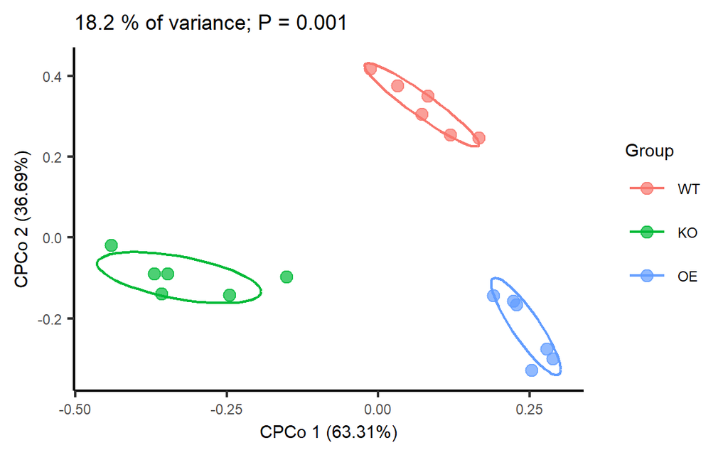

```r
# Plotting Constrained PCoA
(p = beta_cpcoa_dis(distance_mat, metadata, groupID = group))
```

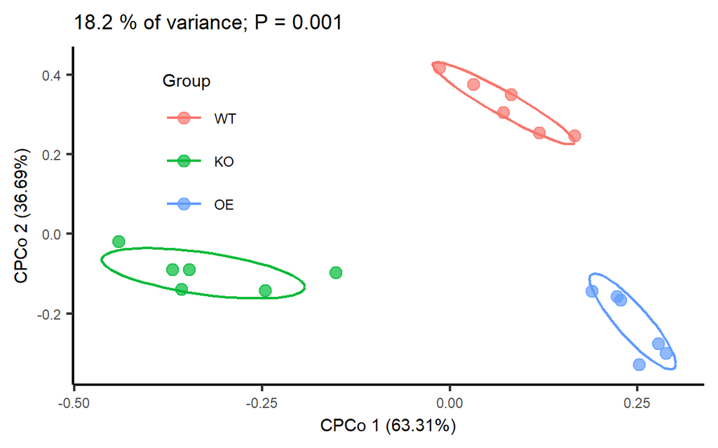

```r
# Legend to top left 图例移至左上
(p = p + theme(legend.position = c(0.2,0.7)))
```

```r
# Saving figure
ggsave(paste0("beta/",distance_type,".cpcoa.pdf"), p, width = width, height = height, units = "mm")
p4 = p
```

## PERMANOVA方差分解

Calculate whether each variable in the metadata has a significant impact on the community structure 计算元数据中各变量是否对群落结构存在显著的影响

```r
# View header 预览元数据表头，确定要分析的变量
head(metadata,n=2)
```

|  | Group | Date | Site | CRA | CRR | BarcodeSequence | LinkerPrimerSequence | ReversePrimer | Batch | Species | Sequencing | Platform | latitude_longitude | Description |
| --- | --- | --- | --- | --- | --- | --- | --- | --- | --- | --- | --- | --- | --- | --- |
| KO1 | KO | 2017/6/30 | Chaoyang | CRA002352 | CRR117575 | ACGCTCGACA | AACMGGATTAGATACCCKG | ACGTCATCCCCACCTTCC | 1 | Arabidopsis thaliana | Novagene | HiSeq2500 | 39.59 N 116.22 E | Knock-out replicate 1 |
| KO2 | KO | 2017/6/30 | Chaoyang | CRA002352 | CRR117576 | ATCAGACACG | AACMGGATTAGATACCCKG | ACGTCATCCCCACCTTCC | 1 | Arabidopsis thaliana | Novagene | HiSeq2500 | 39.59 N 116.22 E | Knock-out replicate 2 |

```r
# Explanation rate of variables仅查看分组对群落的解释
adonis_var <- adonis (as.dist(distance_mat) ~ Group, data = metadata, by=NULL, parallel=4)
adonis_var$aov.tab
```

|  | Df | SumsOfSqs | MeanSqs | F.Model | R2 | Pr(>F) |
| --- | --- | --- | --- | --- | --- | --- |
| Group | 2 | 0.2346863 | 0.11734317 | 2.454063 | 0.2465388 | 0.001 |
| Residuals | 15 | 0.7172382 | 0.04781588 | NA | 0.7534612 | NA |
| Total | 17 | 0.9519245 | NA | NA | 1.0000000 | NA |

```r
write.table(adonis_var$aov.tab, file="beta/adonis_var_group.txt", append = F, sep="\t", quote=F, row.names=T, col.names=T)

# 计算Group, Date, Site三类变量及交互对群落结构差异的解释
adonis_var <- adonis (as.dist(distance_mat) ~ Group*Date*Site, data = metadata, by=NULL, parallel=4)
adonis_var$aov.tab
```

|  | Df | SumsOfSqs | MeanSqs | F.Model | R2 | Pr(>F) |
| --- | --- | --- | --- | --- | --- | --- |
| Group | 2 | 0.2346863 | 0.11734317 | 2.668052 | 0.2465388 | 0.001 |
| Date | 2 | 0.1028775 | 0.05143875 | 1.169572 | 0.1080732 | 0.192 |
| Group:Date | 4 | 0.2185332 | 0.05463329 | 1.242207 | 0.2295699 | 0.101 |
| Residuals | 9 | 0.3958275 | 0.04398083 | NA | 0.4158182 | NA |
| Total | 17 | 0.9519245 | NA | NA | 1.0000000 | NA |

```r
# 变量不能重合，否则无效。如本次Date与Site一致，所以Site无结果

# 计算Group和Site的解释率
adonis_var <- adonis (as.dist(distance_mat) ~ Group*Site, data = metadata, by=NULL, parallel=4)
adonis_var$aov.tab
```

|  | Df | SumsOfSqs | MeanSqs | F.Model | R2 | Pr(>F) |
| --- | --- | --- | --- | --- | --- | --- |
| Group | 2 | 0.2346863 | 0.11734317 | 2.668052 | 0.2465388 | 0.001 |
| Site | 2 | 0.1028775 | 0.05143875 | 1.169572 | 0.1080732 | 0.183 |
| Group:Site | 4 | 0.2185332 | 0.05463329 | 1.242207 | 0.2295699 | 0.090 |
| Residuals | 9 | 0.3958275 | 0.04398083 | NA | 0.4158182 | NA |
| Total | 17 | 0.9519245 | NA | NA | 1.0000000 | NA |

```r
write.table(adonis_var$aov.tab, file="beta/adonis_var.txt", append = F, sep="\t", quote=F, row.names=T, col.names=T)
```

# Taxonomy composition物种组成

## Stackplot 堆叠柱状图

分别绘制样本和组均值的物种组成

Samples and groups

```r
# Set taxonomic level 设置分类级别 门p、纲c、目o、科f、属g
tax_level = "p"
# Data reading
tax_phylum = read.table(paste0("tax/sum_", tax_level, ".txt"), header=T, row.names=1, sep="\t", comment.char="")
tax_phylum[1:3, 1:3]
```

|  | KO1 | KO2 | KO3 |
| --- | --- | --- | --- |
| Proteobacteria | 66.90 | 54.00 | 61.8 |
| Actinobacteria | 24.10 | 36.60 | 26.4 |
| Bacteroidetes | 3.06 | 2.68 | 7.7 |

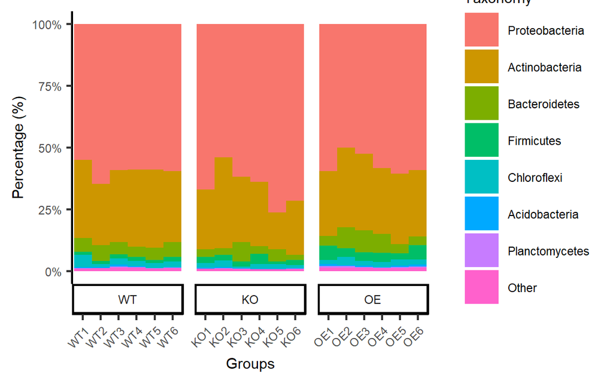

```r
# Plotting samples taxonomy composition
(p = tax_stackplot(tax_phylum, metadata, topN = 8, groupID = group, style = "sample", sorted = "abundance"))
```

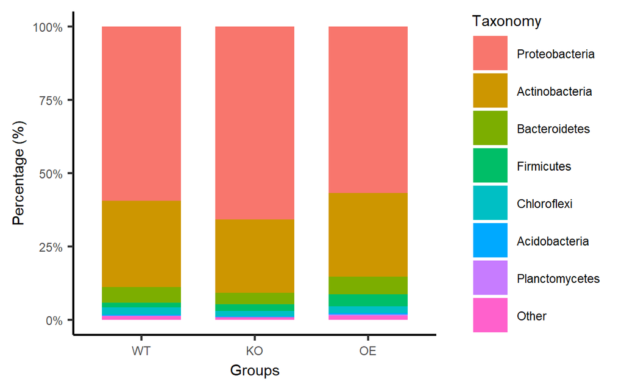

```r
p5 =p
ggsave(paste0("tax/", tax_level,"_sample.pdf"), p, width = width*1.1, height = height, units = "mm")

# Plotting groups taxonomy composition
(p = tax_stackplot(tax_phylum, metadata, topN = 8, groupID = group, style = "group", sorted = "abundance"))
```

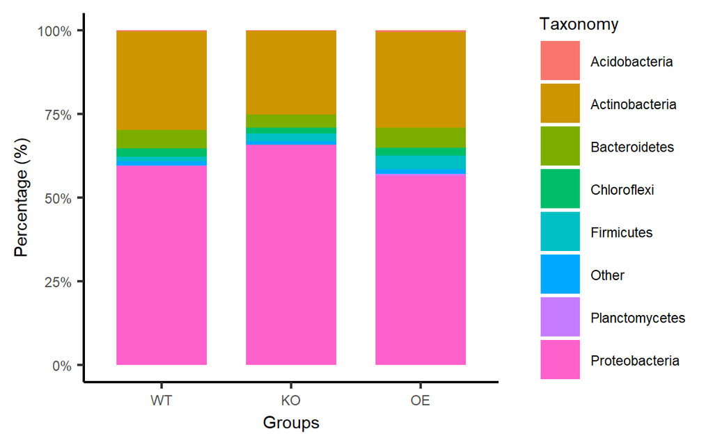

```r
p6 = p
ggsave(paste0("tax/", tax_level,"_group.pdf"), p, width = width*1.1, height = height, units = "mm")

# 按字母顺序排列
(p = tax_stackplot(tax_phylum, metadata, topN = 8, groupID = group, style = "group", sorted = "alphabet"))
```

[figure not shown]

```r
# Change color style 修改配色方案
library(RColorBrewer)
display.brewer.all()
```

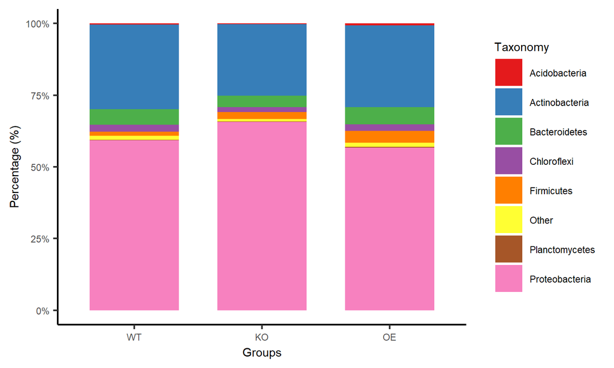

```r
(p = p + scale_fill_brewer(palette = "Set1"))
```

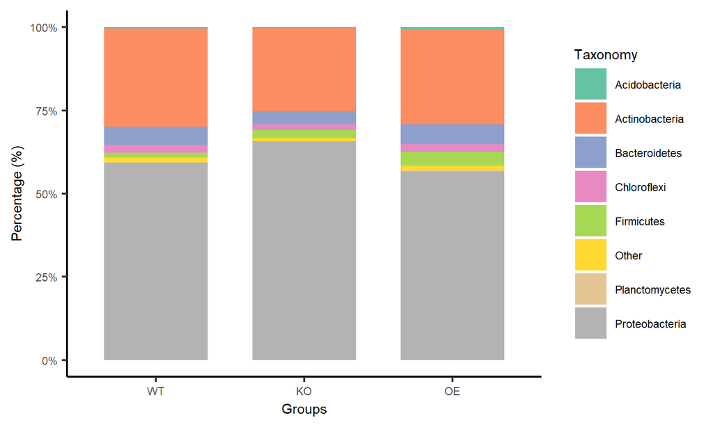

```r
ggsave(paste0("tax/", tax_level,"_group.Set1.pdf"), p, width = width, height = height, units = "mm")
(p = p + scale_fill_brewer(palette = "Set2"))
```

```r
ggsave(paste0("tax/", tax_level,"_group.Set2.pdf"), p, width = width, height = height, units = "mm")
```

## Circlize plot弦图

```r
# 输出结果有当前目录下默认参数的弦图circlize.pdf，每次颜色随机
# 指定颜色和图例的弦图circlize_legend.pdf
tax_circlize(tax_phylum, metadata, topN = 5, groupID = group)
```

```r
# 查看结果不美观，尝试不同水平，如以纲为例
tax_class = read.table(paste0("tax/sum_c.txt"), header=T, row.names=1, sep="\t", comment.char="")
tax_circlize(tax_class, metadata, topN = 8, groupID = group)
```

# Combo plots排版

Combo plots to published-ready figure

组合多个子图为发表格式

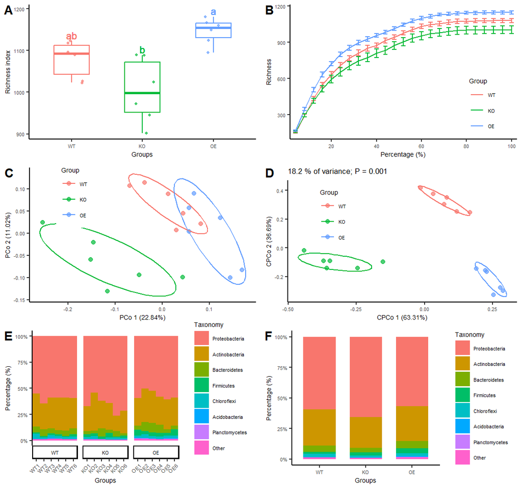

```r
library(cowplot)
(p0 = plot_grid(p1, p2, p3, p4, p5, p6, labels = c("A", "B", "C", "D", "E", "F"), ncol = 2))
```

```r
ggsave("diversity.pdf", p0, width = width * 2, height = height * 3, units = "mm")
```

If used this script, please cited: 使用此脚本，请引用下文：

**Yong-Xin Liu**, Lei Chen, Tengfei Ma, Xiaofang Li, Maosheng Zheng, Xin Zhou, Liang Chen, Xubo Qian, Jiao Xi, Hongye Lu, Huiluo Cao, Xiaoya Ma, Bian Bian, Pengfan Zhang, Jiqiu Wu, Ren-You Gan, Baolei Jia, Linyang Sun, Zhicheng Ju, Yunyun Gao, **Tao Wen**, **Tong Chen**. 2023. EasyAmplicon: An easy-to-use, open-source, reproducible, and community-based pipeline for amplicon data analysis in microbiome research. **iMeta** 2: e83. https://doi.org/10.1002/imt2.83

Copyright 2016-2024 Yong-Xin Liu liuyongxin@caas.cn, Tao Wen taowen@njau.edu.cn, Tong Chen chent@nrc.ac.cn